# DATA2x02 Assignment

540940662

2024-09-08

```r
# {r setup, include=FALSE}
knitr::opts_chunk$set(echo = TRUE)

#| message: false
library(tidyverse)
library(dplyr)
library(stringr)
library(gendercoder)
library(ggplot2)
library(janitor)
library(hms)
library(ggthemes)
theme_set(theme_grey())

# creates a file with the bibtex for packages used:
knitr::write_bib(c(.packages(),
                   "knitr", "rmarkdown"), "refs/packages.bib")
# extra bibliography for manually added references bibliography.bibtex
# ??

# data
x = readxl::read_excel("data/DATA2x02_survey_2024_Responses.xlsx")
```

“Data Analytics: Learning from Data”

```r
# Load the cleaned data from the "data" folder
cleaned_data <- read.csv("data/cleaned_survey_data.csv")
```

# 1 Introduction

< 1. Is this a random sample of DATA2X02 students? >

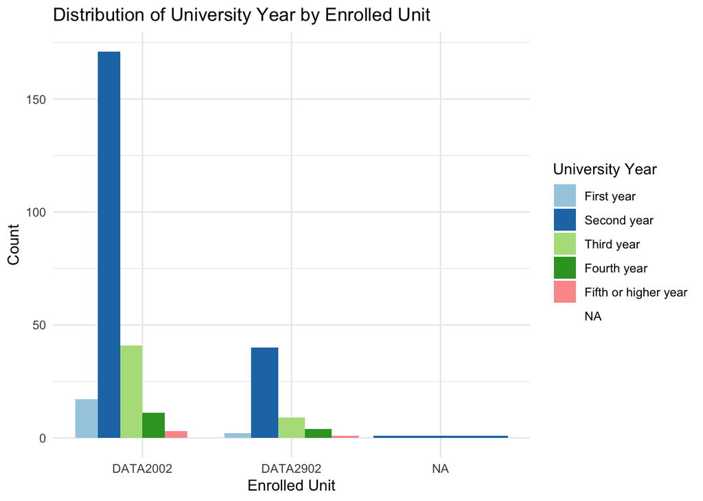

```r
# Create a bar plot
cleaned_data$university_year <- factor(cleaned_data$university_year,
                                       levels = c("First year", "Second year", "Third year","Fourth year", "Fifth or higher year"),
                                       exclude = NULL)  # This includes NA in the factor levels, treated as an additional level

ggplot(cleaned_data, aes(x = enrolled_unit, fill = university_year)) +
  geom_bar(position = "dodge") +
  labs(title = "Distribution of University Year by Enrolled Unit",
       x = "Enrolled Unit",
       y = "Count") +
  theme_minimal() +
  scale_fill_brewer(palette = "Paired", name = "University Year")  # Customize the legend title
```

< 2. What are the potential biases? >

Since it relies on students’ willingness and availability to complete the survey, there might be a self-selection bias. This type of bias occurs when individuals decide whether to participate in the survey, which may result in over- or underrepresentation of certain types of students. For example could we assume more engaged students participate more often.

< Which variables are most likely to be subjected to this bias? >

The study habits variables are likely to be subjected to self-selection bias. This includes target grade, performance, study hours, academic personality, and university year - students who are more diligent or organized might be more likely to participate, skewing the data towards higher study hours or more consistent study routines.

< 3. Which questions needed improvement to generate useful data (e.g. in terms of the way the question was phrased or response validation)? >

The questions that needed the most improvement includes `height`, `shoe_size` and `usual_bedtime`. Common among these variables was that responses included different units which made the interpretation of them almost impossible. Height, being the least impossible of them, still gave reason to difficulties. Firstly, the units where very different. Some answered in cm/centimeter, m/meter, foot/ft, inches, signs(+, ’, ) or just numbers (with or without decimals) without specifying unit. Same goes for the shoe size, this variable was even harder to interpret because of the diversity of how countries define shoe size. Therefore we have no idea if size 10 is Australian, Japanese, European, Chinese and so on and if it is a woman or mans size since that also differs within.  
Overall these two variables beacuse of thier units, made the cleaning and interpretation very difficult. Lastly the variable `usual_bedtime` didn’t specify if the time is given using the 12-hour or 24-hour clock. Therefore we can’t know exactly if a student goes to bad at 6:30 pm or am? We could that 3:30 must be am, but we can’t be certain and thus not let our own bias influence our interpretation of the data. Overall, after a lot of trying to untangle these variables, I decided not to use them in my tests.

# 2 Report structure

Firstly, we will investigate and clean the data. Secondly, we perform and report three hypothesis tests, ensuring that we cover different methods. Lastly, we will summarize the findings and see if we can make any conclusion based on the results from the tests.

## 2.1 Initial data processing

Before cleaning any data, we look through the column to investigate the magnitude of change needed.

# 3 Result

Identify 3 questions you can answer from the data and perform a hypothesis test for each question. The hypotheses should be of the same form as what we have covered in lectures. Give a motivation for why you selected these questions. Be sure to report the hypothesis testing workflow, interpret the results and mention any limitations in the data that may impact your findings. You may have mentioned this in general terms in the introduction, but be specific in the results section.

There needs to be some variety in the types of tests you implement:

- at least one test from module 1
- at least one test from module 2
- at least one test needs to be based on a resampling method (e.g. Monte Carlo or permutation test).

## 3.1 Module 1

### 3.1.1 wk01

**Chi-squared Goodness-of-fit Test**

The only data about gender at Usyd was from 2021. Here the ratio between female and male is 57:43. Lets check if the proportions of gender enrolled in DATA2x02 follows the same distribution.

```r
# 1. Create a new variable 'gender_new' that categorizes into 'female', 'male', and 'other'
cleaned_data <- cleaned_data |>
  mutate(gender_new = case_when(
    gender_clean == "Female" ~ "female",
    gender_clean == "Male" ~ "male",
    TRUE ~ "other"  # Assign 'other' to any remaining gender categories
  ))
unique(cleaned_data$gender_new)
```

```
## [1] "female" "male"   "other"
```

```r
# 2. Calculate the observed distribution of gender in the dataset
observed_gender <- table(cleaned_data$gender_new)
observed_gender_df <- as.data.frame(observed_gender)
observed_gender_df <- observed_gender_df |>
  mutate(proportion = round((Freq / sum(Freq)), digits = 3)) |>
  mutate(exp_prop = c(female = 0.565, male = 0.425, other = 0.01))

observed_gender_df
```

```
##     Var1 Freq proportion exp_prop
## 1 female  121      0.397    0.565
## 2   male  171      0.561    0.425
## 3  other   13      0.043    0.010
```

```r
# 4. Perform the Chi-squared Goodness-of-Fit test
chisq.test(x = observed_gender, p = observed_gender_df$exp_prop)
```

```
##
##  Chi-squared test for given probabilities
##
## data:  observed_gender
## X-squared = 60.953, df = 2, p-value = 5.811e-14
```

Result: reject $H_0$

**Two-sample $t$-test**

```r
# Two-Sample t-Test for independent samples
# Assuming 'used_r_before' is a factor indicating if students have used R ("Yes" or "No")
# and 'weekly_study_hours' is a numeric variable representing the number of study hours per week.

# Subsetting the data into two groups based on the R usage
group_r <- cleaned_data[cleaned_data$used_r_before == "Yes", ]
group_no_r <- cleaned_data[cleaned_data$used_r_before == "No", ]

# Performing the Two-Sample t-Test
t_test_results <- t.test(group_r$weekly_study_hours, group_no_r$weekly_study_hours, var.equal = TRUE)
t_test_results
```

```
##
##  Two Sample t-test
##
## data:  group_r$weekly_study_hours and group_no_r$weekly_study_hours
## t = 0.33169, df = 287, p-value = 0.7404
## alternative hypothesis: true difference in means is not equal to 0
## 95 percent confidence interval:
##  -16.63567  23.37886
## sample estimates:
## mean of x mean of y
##   24.8716   21.5000
```

Hypothesis: Are there differences in average daily sleep hours between males and females?

```r
# Subset male and female sleep hours
male_sleep <- cleaned_data$average_daily_sleep_clean[cleaned_data$gender_clean == "Male"]
female_sleep <- cleaned_data$average_daily_sleep_clean[cleaned_data$gender_clean == "Female"]

# Conduct a two-sample t-test
t_test_independent <- t.test(male_sleep, female_sleep, alternative = "two.sided")

# Output the results
print(t_test_independent)
```

```
##
##  Welch Two Sample t-test
##
## data:  male_sleep and female_sleep
## t = 0.041596, df = 246.37, p-value = 0.9669
## alternative hypothesis: true difference in means is not equal to 0
## 95 percent confidence interval:
##  -0.2871942  0.2995861
## sample estimates:
## mean of x mean of y
##  7.469006  7.462810
```

$H_0 : \mu_1 = \mu_2$

```r
# Subset data for male and female
study_hours_male <- cleaned_data$weekly_study_hours[cleaned_data$gender_clean == "Male"]
study_hours_female <- cleaned_data$weekly_study_hours[cleaned_data$gender_clean == "Female"]

# Run t-test
t.test(study_hours_male, study_hours_female, var.equal = TRUE)
```

```
##
##  Two Sample t-test
##
## data:  study_hours_male and study_hours_female
## t = 0.22996, df = 277, p-value = 0.8183
## alternative hypothesis: true difference in means is not equal to 0
## 95 percent confidence interval:
##  -3.373843  4.266347
## sample estimates:
## mean of x mean of y
##  21.55152  21.10526
```

```r
t.test(study_hours_male, study_hours_female, var.equal = FALSE)
```

```
##
##  Welch Two Sample t-test
##
## data:  study_hours_male and study_hours_female
## t = 0.23476, df = 259.42, p-value = 0.8146
## alternative hypothesis: true difference in means is not equal to 0
## 95 percent confidence interval:
##  -3.296920  4.189424
## sample estimates:
## mean of x mean of y
##  21.55152  21.10526
```

Result: $t_0$ : A low t-value close to 0, such as 0.23476, indicates that the observed difference between the two group means is small. p-value : Don’t reject $H_0$ In this case, a p-value of 0.8146 is much greater than common significance levels (e.g., 0.05). This means there is no evidence to reject the null hypothesis. In other words, we fail to reject the null hypothesis that the mean study hours for males and females are equal.

```
## $Plots
## $Plots[[1]]
## $Plots[[1]]$Histogram
```

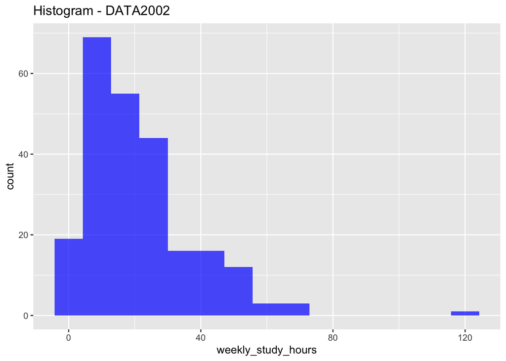

```
##
## $Plots[[1]]$QQPlot
```

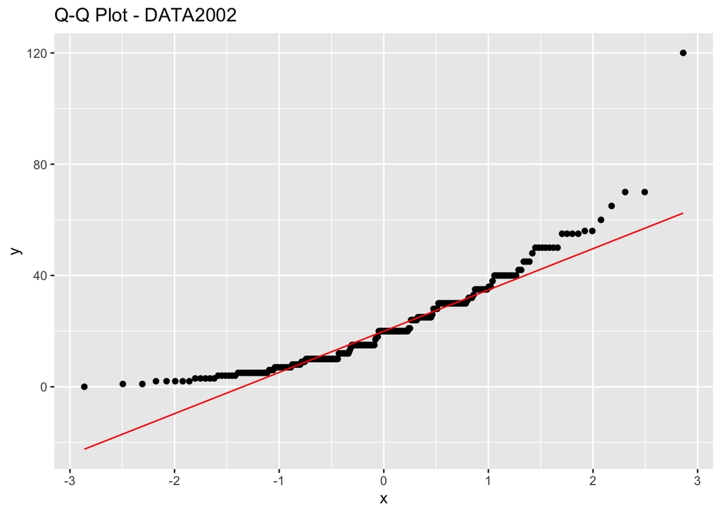

```
##
##
## $Plots[[2]]
## $Plots[[2]]$Histogram
```

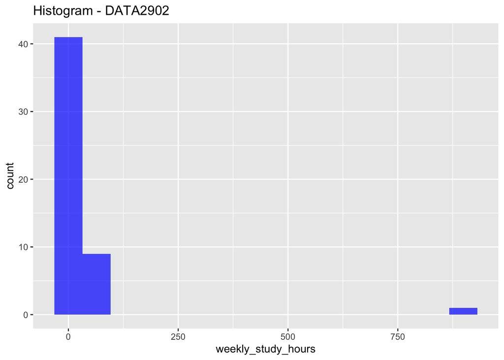

```
##
## $Plots[[2]]$QQPlot
```

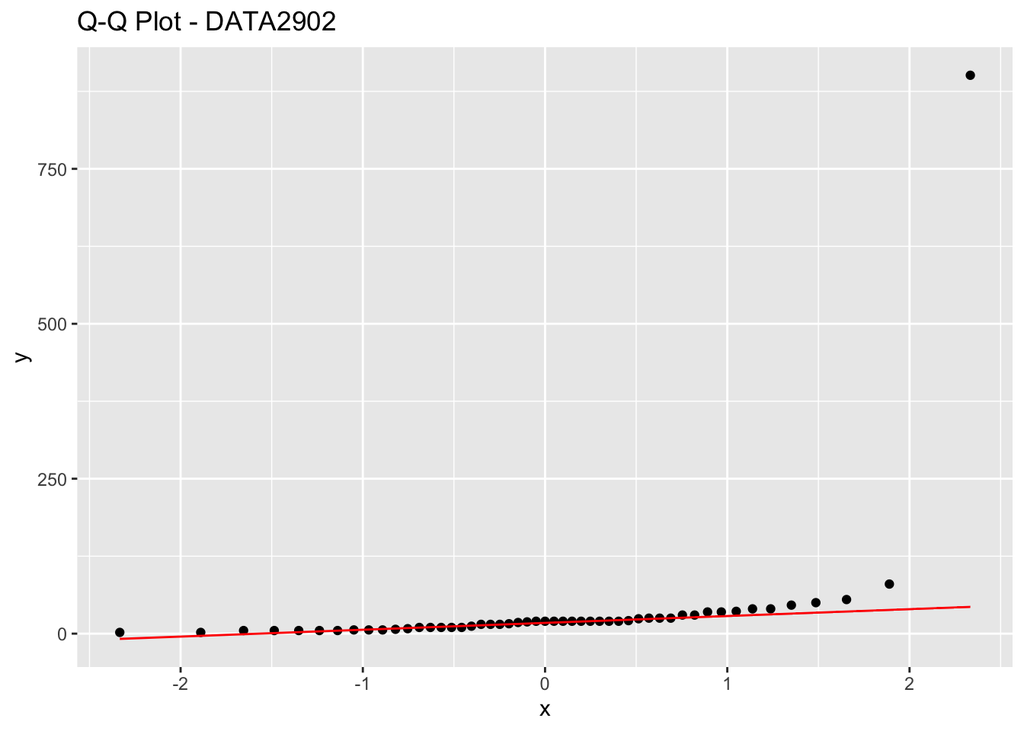

```
##
##
## $Plots[[3]]
## $Plots[[3]]$Histogram
```

[figure not shown]

```
##
## $Plots[[3]]$QQPlot
```

[figure not shown]

```
##
##
##
## $Shapiro_Wilk_Test_Results
##     DATA2002     DATA2902         <NA>
## 1.710222e-12 4.058368e-15           NA
```

```r
# Load necessary library
library(ggplot2)

# Creating histograms and Q-Q plots for each group within 'enrolled_unit'
enrolled_units <- unique(cleaned_data$enrolled_unit)

# Loop through each unique unit and plot
plots_list <- lapply(enrolled_units, function(unit) {
  data_subset <- subset(cleaned_data, enrolled_unit == unit)

  # Histogram
  p1 <- ggplot(data_subset, aes(x = weekly_study_hours)) +
    geom_histogram(bins = 15, fill = "blue", alpha = 0.7) +
    ggtitle(paste("Histogram -", unit))

  # Q-Q Plot
  p2 <- ggplot(data_subset, aes(sample = weekly_study_hours)) +
    stat_qq() +
    stat_qq_line(col = "red") +
    ggtitle(paste("Q-Q Plot -", unit))

  list(Histogram = p1, QQPlot = p2)
})

# Conduct Shapiro-Wilk test for each group, ensuring adequate sample size
shapiro_results <- sapply(enrolled_units, function(unit) {
  data_subset <- subset(cleaned_data, enrolled_unit == unit)

  if (nrow(data_subset) >= 3 && nrow(data_subset) <= 5000) {
    shapiro_test_result <- shapiro.test(data_subset$weekly_study_hours)$p.value
  } else {
    shapiro_test_result <- NA  # Assign NA if sample size is not within the valid range
  }

  return(shapiro_test_result)
})

names(shapiro_results) <- enrolled_units

# Return the list of plots and Shapiro-Wilk test results
list(Plots = plots_list, Shapiro_Wilk_Test_Results = shapiro_results)
```